# Exam_3

Cole Pitt

11/27/2019

Lets load the data and take a look at it!

```r
data <- read.csv(file = "BioLogData_Exam3.csv")
data <- read.csv(file = "BioLogData_Exam3.csv", sep= "|")

summary(data)
```

[output not shown]

Now, Let us **“Run Wild With It!”**

It looks like i will need to use the following tools to answer questions about the data: + summary statistics and visualizations of variables + visualizations of relationships between variables + modeling + statistical tests + transformations, if needed

#### These data are from a “BioLog” machine. Essentially, you put diluted environmental samples into a plate that has a bunch of wells. In each well, there is a unique carbon substrate tagged to a dye. If the microbes in your environmental sample are capable of using that type of carbon substrate, the well will begin to change color.

Courtesy of Dr. Zahn, here is the breakdown of the columns in the data set.

| Column ID | Description |
| --- | --- |
| **Sample.ID** | The location the sample was taken from. There are 2 water samples and 2 soil samples. |
| **Rep** | The experimental replicate. 3 replicates for each combination of experimental variables. |
| **Well** | The well number on the BioLog plate. |
| **Dilution** | The dilution factor of the sample. |
| **Substrate** | The name of the carbon source in that well. “Water” is the negative control. |
| **Hr_24** | The light absorbance value after 24 hours of incubation. |
| **Hr_48** | The light absorbance value after 48 hours of incubation. |
| **Hr_144** | The light absorbance value after 144 hours of incubation. |

Lets look at some plots, run some tests and look at different models. This can help us understand the data more clearly.

## Lets see how much time affects Dilution with some plots.

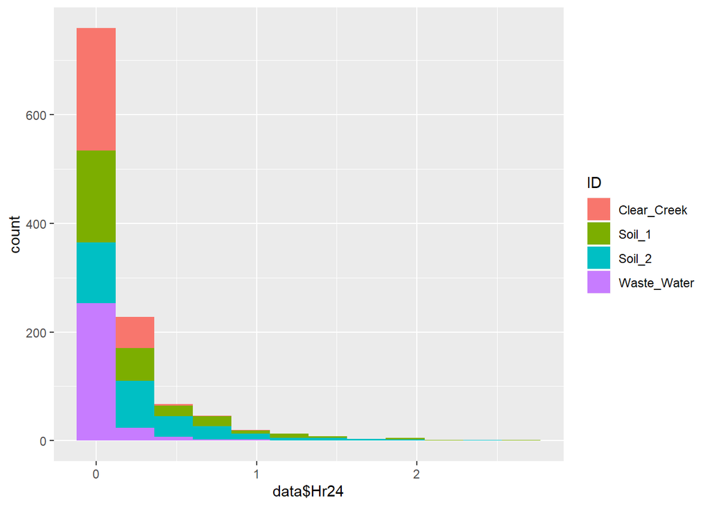

```r
ggplot(data,aes(x=data$Hr24,fill= ID)) +
  geom_histogram(bins = 12)
```

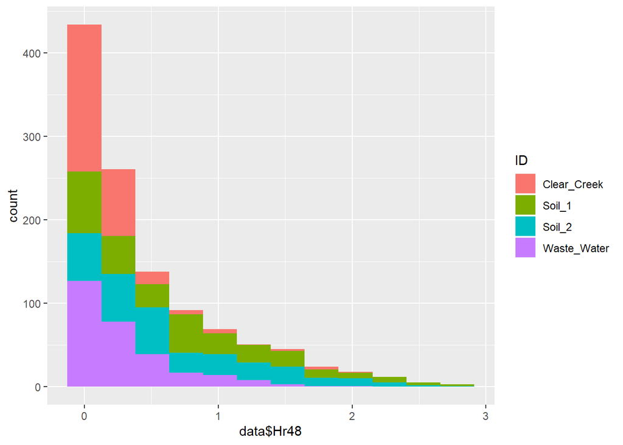

```r
ggplot(data,aes(x=data$Hr48,fill= ID)) +
  geom_histogram(bins = 12)
```

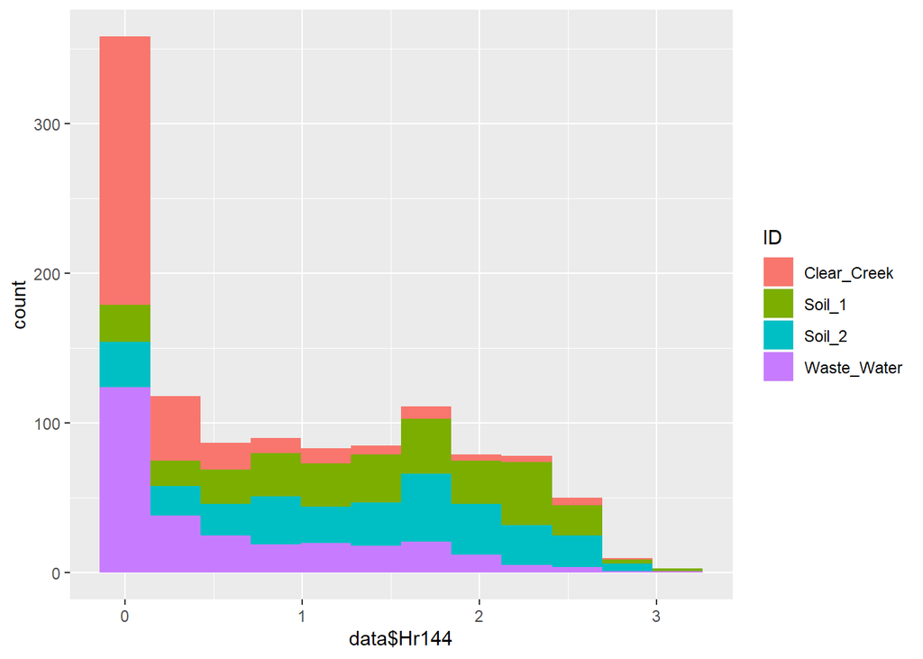

```r
ggplot(data,aes(x=data$Hr144,fill= ID)) +
  geom_histogram(bins = 12)
```

What about the different Substrate?

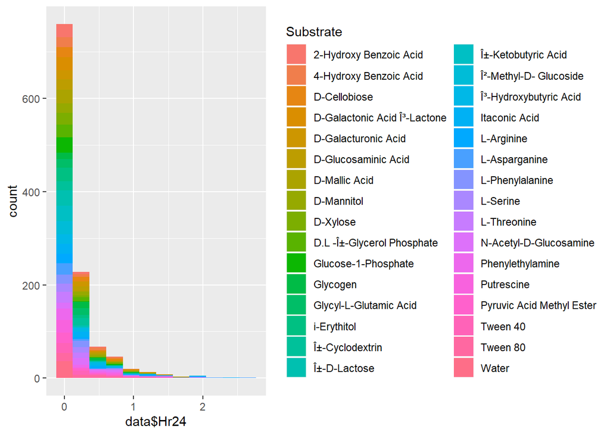

```r
ggplot(data,aes(x=data$Hr24,fill= Substrate)) +
  geom_histogram(bins = 12)
```

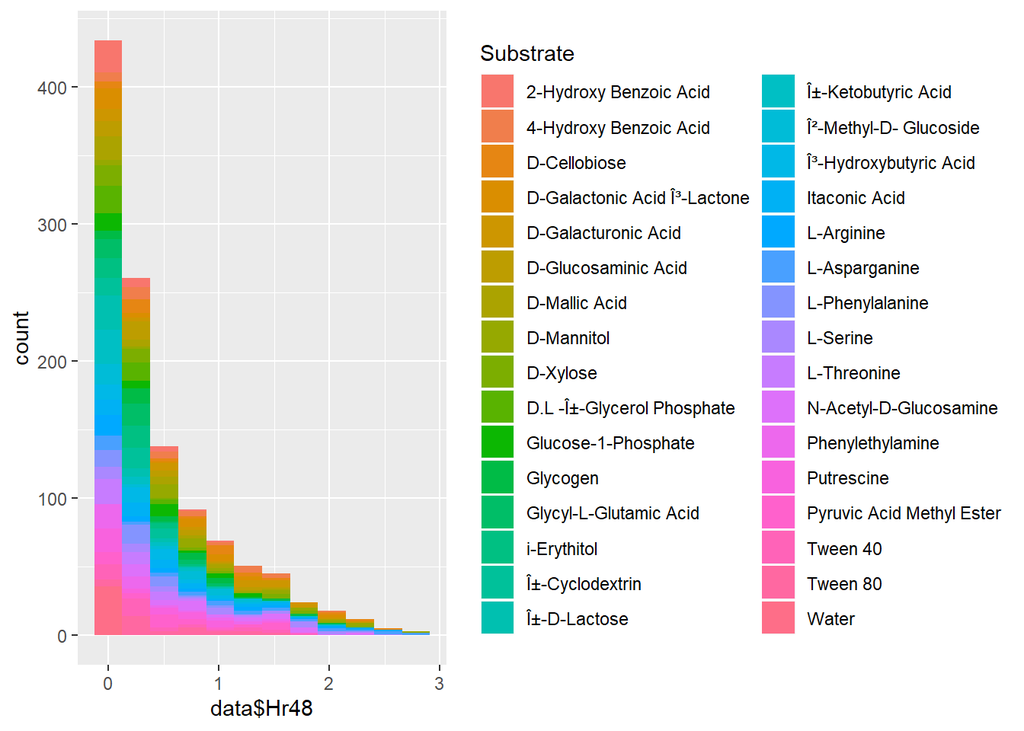

```r
ggplot(data,aes(x=data$Hr48,fill= Substrate)) +
  geom_histogram(bins = 12)
```

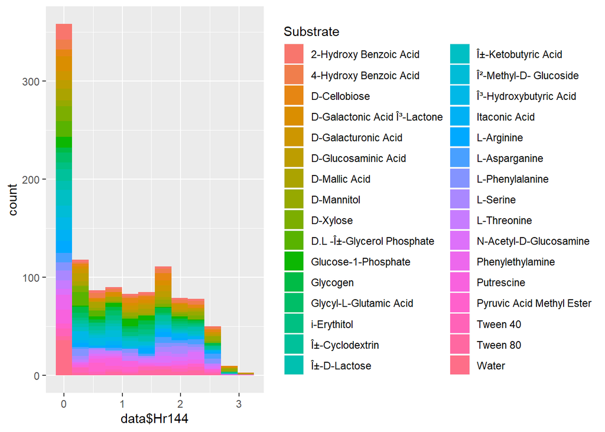

```r
ggplot(data,aes(x=data$Hr144,fill= Substrate)) +
  geom_histogram(bins = 12)
```

cool. but it is hard to understand and read.

We can run some tests to see if time really does affect dilution.

```r
mod24 <- lm(formula = Dilution ~ Hr24, data = data)
summary(mod24)
```

```
##
## Call:
## lm(formula = Dilution ~ Hr24, data = data)
##
## Residuals:
##      Min       1Q   Median       3Q      Max
## -0.03664 -0.03607 -0.02750  0.06237  0.06787
##
## Coefficients:
##              Estimate Std. Error t value Pr(>|t|)
## (Intercept)  0.037644   0.001497  25.146   <2e-16 ***
## Hr24        -0.003784   0.004173  -0.907    0.365
## ---
## Signif. codes:  0 '***' 0.001 '**' 0.01 '*' 0.05 '.' 0.1 ' ' 1
##
## Residual standard error: 0.04472 on 1150 degrees of freedom
## Multiple R-squared:  0.0007146,  Adjusted R-squared:  -0.0001544
## F-statistic: 0.8223 on 1 and 1150 DF,  p-value: 0.3647
```

```r
mod48 <- lm(formula = Dilution ~ Hr48, data = data)
summary(mod48)
```

```
##
## Call:
## lm(formula = Dilution ~ Hr48, data = data)
##
## Residuals:
##      Min       1Q   Median       3Q      Max
## -0.03713 -0.03571 -0.02745  0.06198  0.06650
##
## Coefficients:
##              Estimate Std. Error t value Pr(>|t|)
## (Intercept)  0.038127   0.001710  22.296   <2e-16 ***
## Hr48        -0.002403   0.002324  -1.034    0.301
## ---
## Signif. codes:  0 '***' 0.001 '**' 0.01 '*' 0.05 '.' 0.1 ' ' 1
##
## Residual standard error: 0.04472 on 1150 degrees of freedom
## Multiple R-squared:  0.0009286,  Adjusted R-squared:  5.981e-05
## F-statistic: 1.069 on 1 and 1150 DF,  p-value: 0.3014
```

```r
mod144 <- lm(formula = Dilution ~ Hr144, data = data)
summary(mod144)
```

```
##
## Call:
## lm(formula = Dilution ~ Hr144, data = data)
##
## Residuals:
##      Min       1Q   Median       3Q      Max
## -0.04068 -0.03168 -0.02651  0.05956  0.07303
##
## Coefficients:
##              Estimate Std. Error t value Pr(>|t|)
## (Intercept)  0.041682   0.001923   21.68  < 2e-16 ***
## Hr144       -0.005062   0.001520   -3.33 0.000896 ***
## ---
## Signif. codes:  0 '***' 0.001 '**' 0.01 '*' 0.05 '.' 0.1 ' ' 1
##
## Residual standard error: 0.04452 on 1150 degrees of freedom
## Multiple R-squared:  0.00955,    Adjusted R-squared:  0.008689
## F-statistic: 11.09 on 1 and 1150 DF,  p-value: 0.0008963
```

the only data that is significant is the 144 hour data. The 24 and 48 are not.

What did Sensei Zahn want to know again? Oh yah:

- Which sample locations are functionally different from each other in terms of what C-substrates they can utilize?

Split them all up and look.

```r
unique(data$ID)
```

```
## [1] Clear_Creek Soil_1      Soil_2      Waste_Water
## Levels: Clear_Creek Soil_1 Soil_2 Waste_Water
```

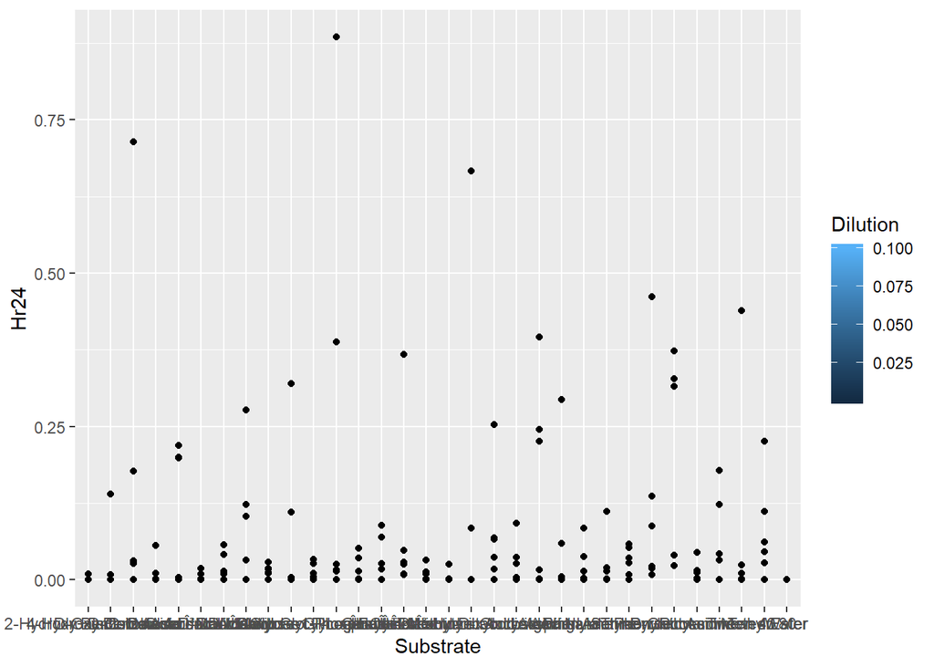

```r
clearwater <- subset(x = data, ID == "Clear_Creek")
wastewater <- subset(x = data, ID == "Waste_Water")
soil1 <- subset(x = data, ID == "Soil_1")
soil2 <- subset(x = data, ID == "Soil_2")


ggplot(wastewater,aes(x=Substrate,y= Hr24, fill=Dilution)) +
  geom_point()
```

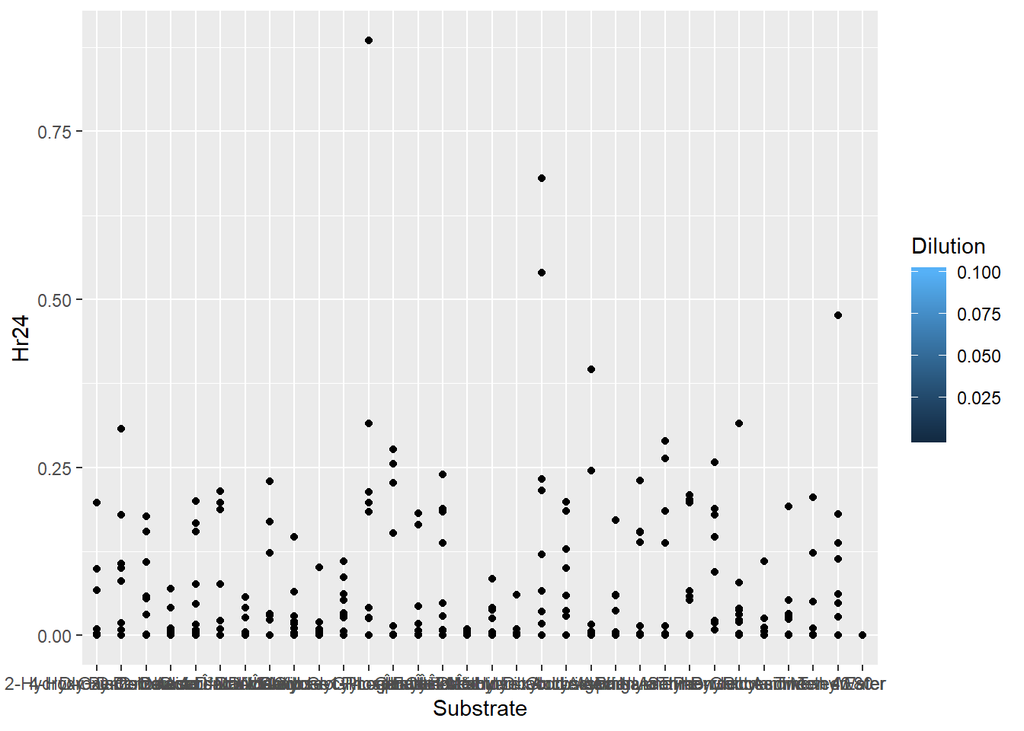

```r
ggplot(clearwater,aes(x=Substrate,y= Hr24, fill=Dilution)) +
  geom_point()
```

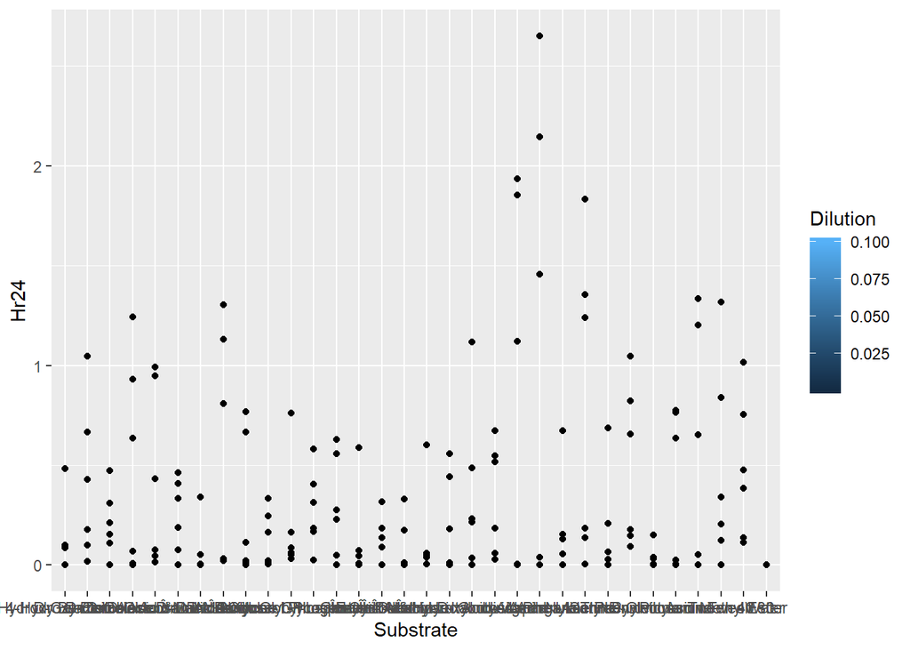

```r
ggplot(soil1,aes(x=Substrate,y= Hr24, fill=Dilution)) +
  geom_point()
```

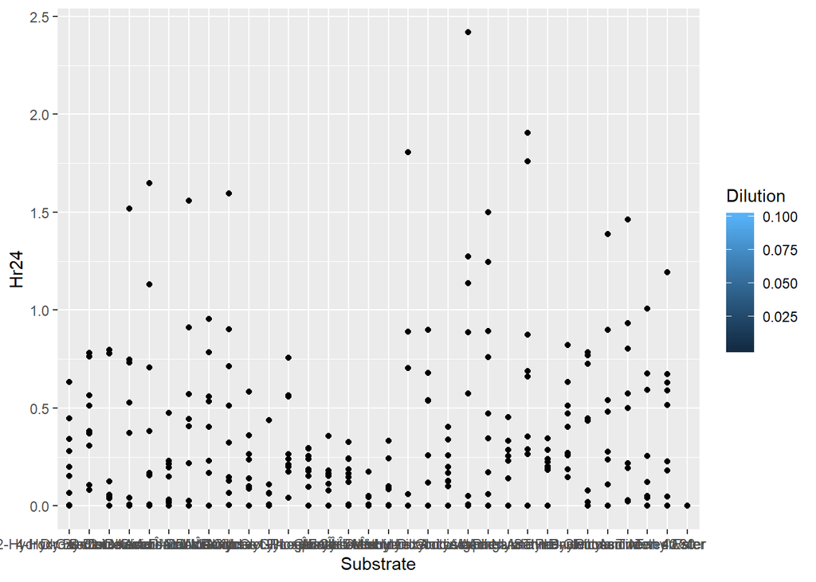

```r
ggplot(soil2,aes(x=Substrate,y= Hr24, fill=Dilution)) +
  geom_point()
```

- Are Soil and Water samples significantly different overall (as in, overall diversity of usable carbon sources)? What about for individual carbon substrates?
- If there are differences between samples, which C-substrates are driving those differences?
- Does the dilution factor change any of these answers?
- Do the control samples indicate any contamination?

Water is the negative control so you will need to see if there is any dilution in the water. If there are none, it means there was no contamination.

```r
contamination <-data %>%
  filter(data$Substrate == "Water")
contamination
```

```
##             ID Rep Well Dilution Substrate Hr24 Hr48 Hr144
## 1  Clear_Creek   1   A1    0.001     Water    0    0     0
## 2  Clear_Creek   1   A1    0.010     Water    0    0     0
## 3  Clear_Creek   1   A1    0.100     Water    0    0     0
## 4  Clear_Creek   2   A1    0.001     Water    0    0     0
## 5  Clear_Creek   2   A1    0.010     Water    0    0     0
## 6  Clear_Creek   2   A1    0.100     Water    0    0     0
## 7  Clear_Creek   3   A1    0.001     Water    0    0     0
## 8  Clear_Creek   3   A1    0.010     Water    0    0     0
## 9  Clear_Creek   3   A1    0.100     Water    0    0     0
## 10      Soil_1   1   A1    0.001     Water    0    0     0
## 11      Soil_1   1   A1    0.010     Water    0    0     0
## 12      Soil_1   1   A1    0.100     Water    0    0     0
## 13      Soil_1   2   A1    0.001     Water    0    0     0
## 14      Soil_1   2   A1    0.010     Water    0    0     0
```

[output cut: 22 more lines]